# Welcome to the Tidyverse

### Facet_wrap()

Un’altra funzione utile per costruire più grafici contemporaneamente è `facet_wrap()` che consente di costruire grafci in base a fino a due variabili categoriche:

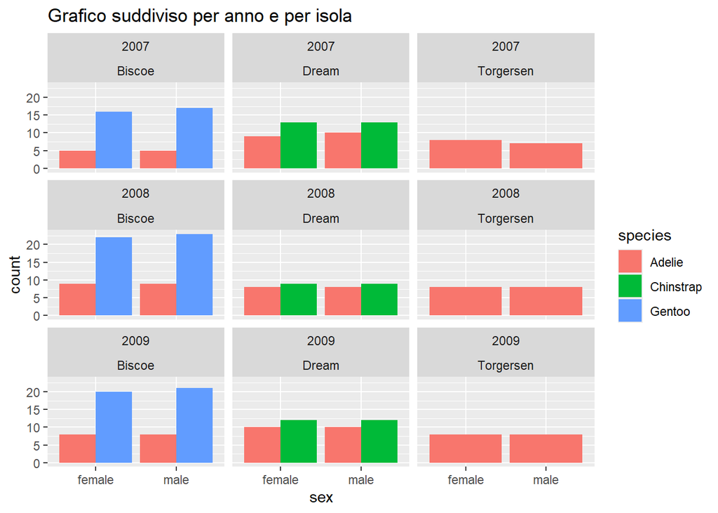

```r
penguins %>%
  drop_na() %>%

  ggplot(aes(x = sex, fill = species)) +
  geom_bar(position = position_dodge()) +
  ggtitle("Grafico suddiviso per anno e per isola") + # aggiungi titolo
  facet_wrap(year~island) # suddividi il grafico per anno e per isola
```

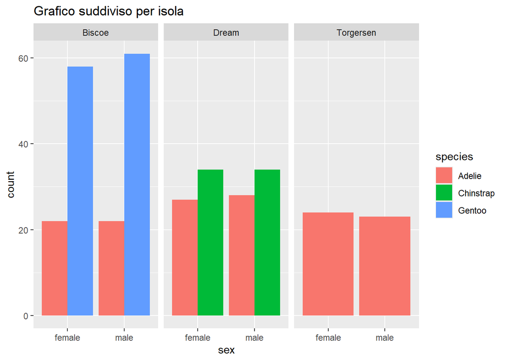

```r
penguins %>%
  drop_na() %>%

  ggplot(aes(x = sex, fill = species)) +
  geom_bar(position = position_dodge()) +
  ggtitle("Grafico suddiviso per isola") + # aggiungi titolo
  facet_wrap(~island) # suddividi il grafico per isola
```

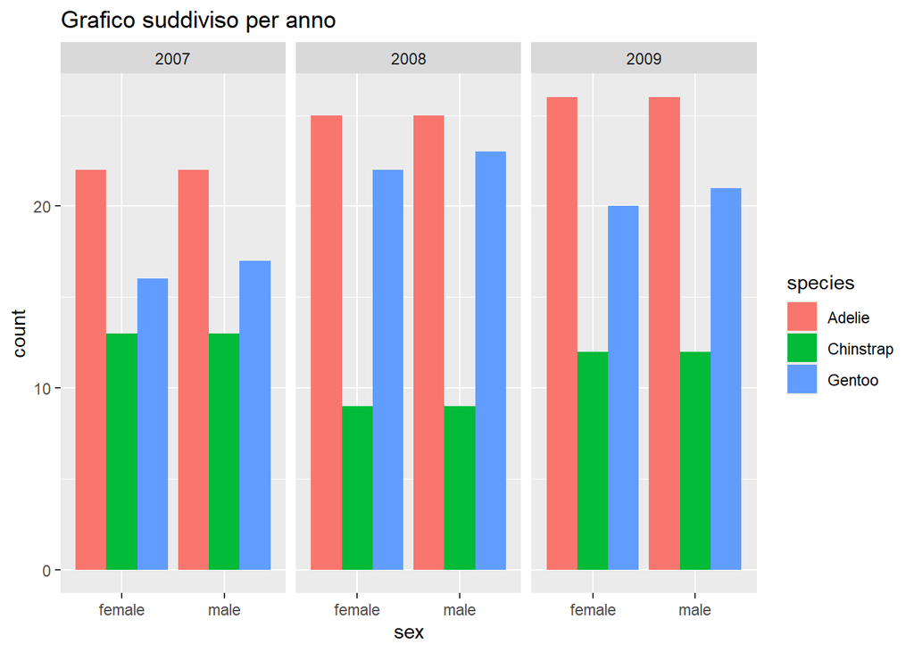

```r
penguins %>%
  drop_na() %>%

  ggplot(aes(x = sex, fill = species)) +
  geom_bar(position = position_dodge()) +
  ggtitle("Grafico suddiviso per anno") + # aggiungi titolo
  facet_wrap(year~.) # sddividi il grafico per anno
```

### pivot_longer() e pivot_wider()

Come abbiamo visto ggplot ragiona per colonna, non per riga. Tuttavia, ci sono delle situazioni in cui questo ragionare per colonna non ci aiuta a plottare certi tipi di dati, ad esempio diverse serie temporali come riportate qui sotto:

```r
set.seed(1) # rendo riproducibili i numeri casuali
df0 <- data.frame(
  t = seq(0, 10)   # creo un data frame con una colonna t con valori da 0 a 10
) %>%
  mutate( # aggiungo 6 colonne y che seguono la legge e^(-k*t) dove k è un numero casuale da 0 a 1. (cinetica primo ordine)
    y1 = exp(-runif(1) * t),
    y2 = exp(-runif(1) * t),
    y3 = exp(-runif(1) * t),
    y4 = exp(-runif(1) * t),
    y5 = exp(-runif(1) * t),
    y6 = exp(-runif(1) * t)
  )
df0
```

| t | y1 | y2 | y3 | y4 | y5 | y6 |
| --- | --- | --- | --- | --- | --- | --- |
| 0 | 1.00000000 | 1.00000000 | 1.000000000 | 1.0000000000 | 1.0000000 | 1.0000000000 |
| 1 | 0.76681580 | 0.68926884 | 0.563914089 | 0.4032462788 | 0.8173549 | 0.4072248924 |
| 2 | 0.58800647 | 0.47509153 | 0.317999100 | 0.1626075614 | 0.6680690 | 0.1658321130 |
| 3 | 0.45089265 | 0.32746579 | 0.179324173 | 0.0655708940 | 0.5460494 | 0.0675309644 |
| 4 | 0.34575161 | 0.22571196 | 0.101123428 | 0.0264412190 | 0.4463161 | 0.0275002897 |
| 5 | 0.26512780 | 0.15557622 | 0.057024926 | 0.0106623232 | 0.3647987 | 0.0111988025 |
| 6 | 0.20330418 | 0.10723384 | 0.032157159 | 0.0042995421 | 0.2981700 | 0.0045604311 |
| 7 | 0.15589686 | 0.07391294 | 0.018133875 | 0.0017337744 | 0.2437107 | 0.0018571211 |
| 8 | 0.11954418 | 0.05094589 | 0.010225948 | 0.0006991381 | 0.1991981 | 0.0007562659 |
| 9 | 0.09166836 | 0.03511541 | 0.005766556 | 0.0002819248 | 0.1628155 | 0.0003079703 |

[output cut: 1 more lines]

questo potrebbe essere un tipico import di dati in cui ogni colonna rappresenta la concentrazione di un reagente sottoposto a sei condizioni di degradazione diverse. Se dovessi plottare questi dati con ggplot dovrei scrivere un codice molto lungo e dovrei cambiare le aes per ogni elemento geom_ aggiunto:

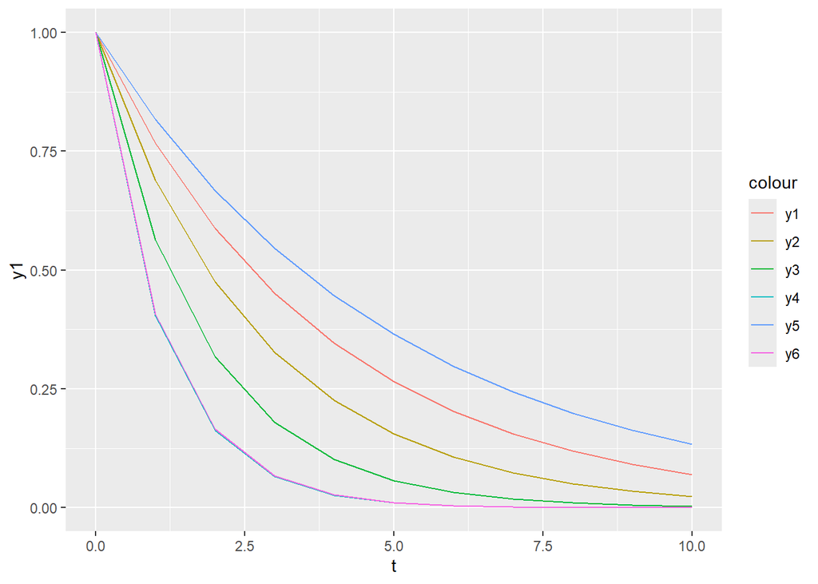

```r
df0 %>%
  ggplot(aes(x = t)) + # assegno un valore comune a x che è il tempo
  geom_line(aes(y = y1, col = "y1")) + # i valori di y qui saranno di y1 e il colore di "y1"
  geom_line(aes(y = y2, col = "y2")) +
  geom_line(aes(y = y3, col = "y3")) +
  geom_line(aes(y = y4, col = "y4")) +
  geom_line(aes(y = y5, col = "y5")) +
  geom_line(aes(y = y6, col = "y6"))
```

NB: assegnare un valore al colore dento aes() non definisce il colore! ggplot assegna un valore di colore secondo la sua palette. Il valore che date voi è il nome che verrà visualizzato in legenda!

In questo caso sono poche righe di codice, ma nel caso di prove con un numero considerevole di repliche questa strategia è deleteria, a maggior ragione se dobbiamo utilizzare più elementi grafici contemporaneamente. In nostro aiuto possiamo chiamare la funzione `pivot_longer()`. pivot_longer prende n colonne numeriche e le trasforma in due colonne inserendo tutti i valori presi dalle varie colonne in una sola mentre nella seconda colonna viene riportato il nome della colonna da cui è stato preso il valore. La funzione `pivot_wider()` fa esattamente l’operazione inversa, ovvero date in input una colonna di caratteri e una di valori rimodella il dataframe in modo da creare n colonne quanti sono i caratteri distinti della prima colonna e inserisce all’interno di ogni colonna i valori che appartenevano alla stessa riga. é più facile a farlo che spiegarlo.

Prendiamo questo semplice data frame a titolo di esempio per pivot longer:

```r
data.frame(ID = c("#1", "#2", "#3"), a = c(1,2,3), b = c(4,5,6))
```

| ID | a | b |
| --- | --- | --- |
| #1 | 1 | 4 |
| #2 | 2 | 5 |
| #3 | 3 | 6 |

applicando pivot longer alle colonne a e b:

```r
data.frame(ID = c("#1", "#2", "#3"), a = c(1,2,3), b = c(4,5,6)) %>%
  pivot_longer(c(a,b))
```

| ID | name | value |
| --- | --- | --- |
| #1 | a | 1 |
| #1 | b | 4 |
| #2 | a | 2 |
| #2 | b | 5 |
| #3 | a | 3 |
| #3 | b | 6 |

come vediamo i nomi delle colonne ora sono nella colonna names e i valori contenuti sono nella colonna values. I valori che erano conenuti in a avranno un corrispondente valore in riga “a” mentre i valori che erano contenuti nella colonna b avranno un corrispondente valore “b”. I valori di ID rimangono quelli assegnati in principio e vengono duplicati se necessario.

pivot_wider fa esattamente l’opposto, solo che devo specificare la colonna da cui prendere i nomi e quella da cui prendere i valori:

```r
data.frame(ID = c("#1", "#2", "#3"), a = c(1,2,3), b = c(4,5,6)) %>%
  pivot_longer(c(a,b)) %>%
  pivot_wider(names_from = "name", values_from = "value")
```

| ID | a | b |
| --- | --- | --- |
| #1 | 1 | 4 |
| #2 | 2 | 5 |
| #3 | 3 | 6 |

ed ecco il dataframe di prima!

Riprendiamo ora il nostro dataframe con le cinetiche

```r
df0
```

| t | y1 | y2 | y3 | y4 | y5 | y6 |
| --- | --- | --- | --- | --- | --- | --- |
| 0 | 1.00000000 | 1.00000000 | 1.000000000 | 1.0000000000 | 1.0000000 | 1.0000000000 |
| 1 | 0.76681580 | 0.68926884 | 0.563914089 | 0.4032462788 | 0.8173549 | 0.4072248924 |
| 2 | 0.58800647 | 0.47509153 | 0.317999100 | 0.1626075614 | 0.6680690 | 0.1658321130 |
| 3 | 0.45089265 | 0.32746579 | 0.179324173 | 0.0655708940 | 0.5460494 | 0.0675309644 |
| 4 | 0.34575161 | 0.22571196 | 0.101123428 | 0.0264412190 | 0.4463161 | 0.0275002897 |
| 5 | 0.26512780 | 0.15557622 | 0.057024926 | 0.0106623232 | 0.3647987 | 0.0111988025 |
| 6 | 0.20330418 | 0.10723384 | 0.032157159 | 0.0042995421 | 0.2981700 | 0.0045604311 |
| 7 | 0.15589686 | 0.07391294 | 0.018133875 | 0.0017337744 | 0.2437107 | 0.0018571211 |
| 8 | 0.11954418 | 0.05094589 | 0.010225948 | 0.0006991381 | 0.1991981 | 0.0007562659 |
| 9 | 0.09166836 | 0.03511541 | 0.005766556 | 0.0002819248 | 0.1628155 | 0.0003079703 |

[output cut: 1 more lines]

Per plottare tutte le curve in poche linee di codice possiamo usare pivot_longer():

```r
df0 %>%
  pivot_longer(y1:y6) # le colonne da y1 a y6
```

| t | name | value |
| --- | --- | --- |
| 0 | y1 | 1.0000000000 |
| 0 | y2 | 1.0000000000 |
| 0 | y3 | 1.0000000000 |
| 0 | y4 | 1.0000000000 |
| 0 | y5 | 1.0000000000 |
| 0 | y6 | 1.0000000000 |
| 1 | y1 | 0.7668157998 |
| 1 | y2 | 0.6892688371 |
| 1 | y3 | 0.5639140891 |
| 1 | y4 | 0.4032462788 |

[output cut: 56 more lines]

applicando pivot longer otteniamo tutti i valori di concentrazione in un unica colonna, associati al valore del tempo in cui sono stati misurati e al nome della colonna. Fare un grafico con ggplot ora è un gioco da ragazzi:

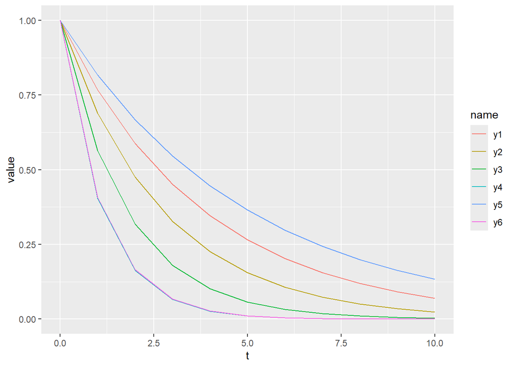

```r
df0 %>%
  pivot_longer(y1:y6) %>%

  ggplot(aes(x = t,
             y = value, # prendi i valori di y dalla colonna value
             colour = name # assegna i colori in base alla colonna name: ovvero ogni experimento avrà un suo colore
             )) +
  geom_line()
```

oppure con facet_wrap:

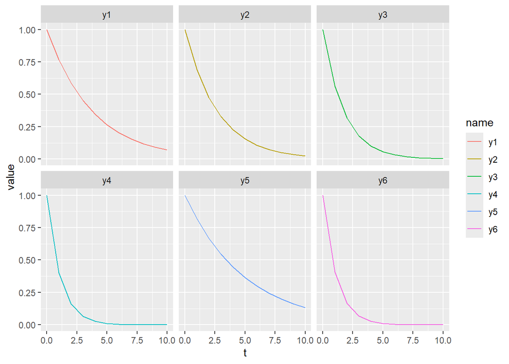

```r
df0 %>%
  pivot_longer(y1:y6) %>%

  ggplot(aes(x = t,
             y = value, # prendi i valori di y dalla colonna value
             colour = name # assegna i colori in base alla colonna name: ovvero ogni experimento avrà un suo colore
             )) +
  geom_line() +
  facet_wrap(~name)
```

In caso di tabelle ricche di dati, queste funzioni consentono di costruire grafici e analizzare i dati molto più velocemente. Ad esempio se volessi costruire un grafico con il dataset penguins in cui mostro contemporaneamente bill_length, bill_depth e flipper_length in funzione della body_mass e colorare in base alla specie posso usare il seguente codice:

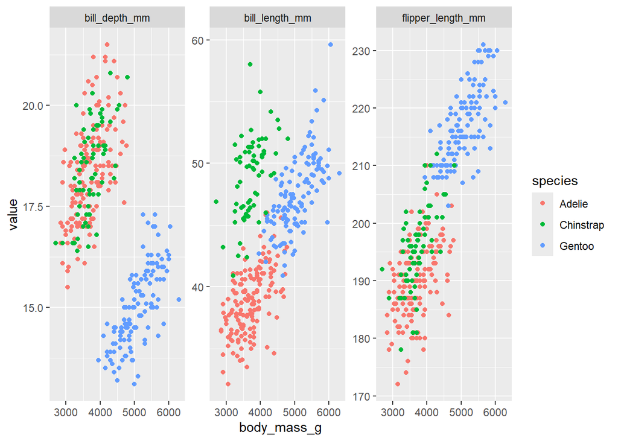

```r
penguins %>%
  pivot_longer(bill_length_mm:flipper_length_mm) %>% # pivot_longer delle colonne da bill_length a flipper_length

  ggplot(aes(x = body_mass_g, y = value, col = species)) +
  geom_point() + facet_wrap(~name,
                            scales = "free_y" # la scala valori delle y non è uguale nei facets
                            )
```

immaginate quante linee di codice avreste dovuto scrivere senza `pivot_longer()`!

### Reframe() (o summarise()) e group_by()

Reframe consente di creare un nuovo dataframe a partire dai dati del vecchio. Ad esempio se volessi un nuovo dataframe con solo le medie delle lunghezze e profondità del becco:

```r
p1 %>%
  drop_na(bill_length_mm, bill_depth_mm) %>%
  # dai dati del vecchio dataframe costruiscine uno nuvo con le seguenti colonne:
  reframe(mean_bill_length = mean(bill_length_mm), # conterrà la media dei valori di bill_length
          mean_bill_depth = mean(bill_depth_mm)    # conterrà la media dei valori di bill_depth
          )
```

| mean_bill_length | mean_bill_depth |
| --- | --- |
| 43.92193 | 17.15117 |

Usato in combinazione con `group_by()` consente di applicare le funzioni in base al valore di un’altra colonna. Ad esempio, se volessi le medie in base alla specie con anche la deviazione standard:

```r
pm <- p1 %>%
  drop_na(bill_length_mm, bill_depth_mm) %>%
  group_by(species) %>% # raggruppa in base al valore che trovi in specie
  # costruisci un nuovo dataframe usando i dati del vecchio
  reframe(mean_bill_length = mean(bill_length_mm),
          sd_bill_length = sd(bill_length_mm),
          mean_bill_depth = mean(bill_depth_mm),
          sd_bill_depth = sd(bill_depth_mm)
          )
pm
```

| species | mean_bill_length | sd_bill_length | mean_bill_depth | sd_bill_depth |
| --- | --- | --- | --- | --- |
| Adelie | 38.79139 | 2.663405 | 18.34636 | 1.2166498 |
| Chinstrap | 48.83382 | 3.339256 | 18.42059 | 1.1353951 |
| Gentoo | 47.50488 | 3.081857 | 14.98211 | 0.9812198 |

da notare che la colonna `species` è rimasta anche se non era stata inserita in reframe. Questo perché avendo raggruppato per i valori di species `reframe()` la tiene in automatico.

Costruiamo il grafico dei valori medi di bill_length con le bande dell’errore:

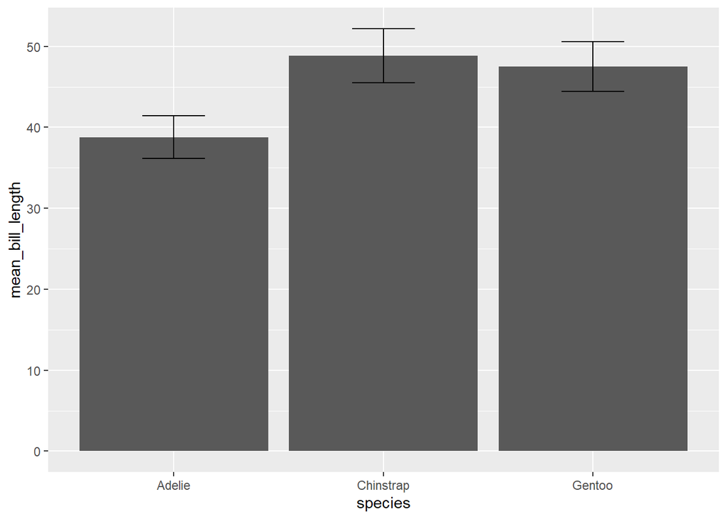

```r
pm %>%
  ggplot(aes(x = species,
             y = mean_bill_length,
             ymax = mean_bill_length + sd_bill_length, # valore massimo di y media + dev std
             ymin = mean_bill_length - sd_bill_length  # valore massimo di y media - dev std
             )) + geom_col() +
  geom_errorbar(  # costruisce barre dellerrore
    width = 0.3 # aggiusta la larghezza delle barre orizontali
    )
```

Se uso la funzione `ungroup()` dopo aver usato `group_by()`, rimuovo il raggruppamento:

```r
p1 %>%
  drop_na(bill_length_mm, bill_depth_mm) %>%
  group_by(species) %>% # ragguppo
  ungroup() %>% # tolgo il raggruppamento: ora reframe non terrà conto della specie
  reframe(mean_bill_length = mean(bill_length_mm),
          sd_bill_length = sd(bill_length_mm),
          mean_bill_depth = mean(bill_depth_mm),
          sd_bill_depth = sd(bill_depth_mm)
          )
```

| mean_bill_length | sd_bill_length | mean_bill_depth | sd_bill_depth |
| --- | --- | --- | --- |
| 43.92193 | 5.459584 | 17.15117 | 1.974793 |

### full_join()

Una funzione utile per unire diversi dataframe relativi agli stessi dati è `full_join()`.

Vogliamo calclare il discostamento dalla media di specie per ogni pinguino. Un modo efficace è usare la funzione `full_join()` per unire i dataframe `pm` che contiene le medie e `penguins` che contiene i valori degli individui. Successivamente possiamo comuputare la differenza in una colonna a parte con `mutate()`.

Partiamo dal codice per il calcolo della media. Immaginiamo che sia un dataframe fornito e non siamo stati noi a crearlo. Prima di unire i daframe voglio togliere le due colonne delle deviazioni standard. Uso la funzione `select()` in combinazione con `starts_with()`:

```r
pm %>%
  # seleziona tutto tranne le colonne che cominciano per "sd_"
  select(-starts_with("sd_"))
```

| species | mean_bill_length | mean_bill_depth |
| --- | --- | --- |
| Adelie | 38.79139 | 18.34636 |
| Chinstrap | 48.83382 | 18.42059 |
| Gentoo | 47.50488 | 14.98211 |

```r
  # altre funzioni utilizzabili dentro select sono ends_with() o contains()
```

Ora unisco il dataframe delle medie con il precedente. Per farlo devo indicare una colonna che funga da indice per associare i valori. In questo caso vogliamo unire i dataframe in base alla specie. Posso usare anche due colonne contemporaneamente come indici. NB: le colonne usate come indice devono avere lo stesso nome.

```r
pm %>%
  select(-starts_with("sd_")) %>%

  # unisci questo dataframe con il dataframe p1 indicizzando per la colonna species
  full_join(p1, by = join_by(species))
```

| species | mean_bill_length | mean_bill_depth | ID | island | bill_length_mm | bill_depth_mm | flipper_length_mm | body_mass_g | sex | year |
| --- | --- | --- | --- | --- | --- | --- | --- | --- | --- | --- |
| Adelie | 38.79139 | 18.34636 | p001 | Torgersen | 39.1 | 18.7 | 181 | 3750 | male | 2007 |
| Adelie | 38.79139 | 18.34636 | p002 | Torgersen | 39.5 | 17.4 | 186 | 3800 | female | 2007 |
| Adelie | 38.79139 | 18.34636 | p003 | Torgersen | 40.3 | 18.0 | 195 | 3250 | female | 2007 |
| Adelie | 38.79139 | 18.34636 | p004 | Torgersen | NA | NA | NA | NA | NA | 2007 |
| Adelie | 38.79139 | 18.34636 | p005 | Torgersen | 36.7 | 19.3 | 193 | 3450 | female | 2007 |
| Adelie | 38.79139 | 18.34636 | p006 | Torgersen | 39.3 | 20.6 | 190 | 3650 | male | 2007 |
| Adelie | 38.79139 | 18.34636 | p007 | Torgersen | 38.9 | 17.8 | 181 | 3625 | female | 2007 |
| Adelie | 38.79139 | 18.34636 | p008 | Torgersen | 39.2 | 19.6 | 195 | 4675 | male | 2007 |
| Adelie | 38.79139 | 18.34636 | p009 | Torgersen | 34.1 | 18.1 | 193 | 3475 | NA | 2007 |
| Adelie | 38.79139 | 18.34636 | p010 | Torgersen | 42.0 | 20.2 | 190 | 4250 | NA | 2007 |

[output cut: 334 more lines]

da qui con mutate posso calcolare i residui dal valore medio:

```r
pm %>%
  select(-starts_with("sd_")) %>%
  full_join(p1, by = join_by(species)) %>%
  mutate(res_bill_length = mean_bill_length - bill_length_mm,
         res_bill_depth = mean_bill_depth - bill_depth_mm,
         .before = ID # inserisci le colonne prima della colonna ID
         )
```

| species | mean_bill_length | mean_bill_depth | res_bill_length | res_bill_depth | ID | island | bill_length_mm | bill_depth_mm | flipper_length_mm | body_mass_g | sex | year |
| --- | --- | --- | --- | --- | --- | --- | --- | --- | --- | --- | --- | --- |
| Adelie | 38.79139 | 18.34636 | -0.308609272 | -0.35364238 | p001 | Torgersen | 39.1 | 18.7 | 181 | 3750 | male | 2007 |
| Adelie | 38.79139 | 18.34636 | -0.708609272 | 0.94635762 | p002 | Torgersen | 39.5 | 17.4 | 186 | 3800 | female | 2007 |
| Adelie | 38.79139 | 18.34636 | -1.508609272 | 0.34635762 | p003 | Torgersen | 40.3 | 18.0 | 195 | 3250 | female | 2007 |
| Adelie | 38.79139 | 18.34636 | NA | NA | p004 | Torgersen | NA | NA | NA | NA | NA | 2007 |
| Adelie | 38.79139 | 18.34636 | 2.091390728 | -0.95364238 | p005 | Torgersen | 36.7 | 19.3 | 193 | 3450 | female | 2007 |
| Adelie | 38.79139 | 18.34636 | -0.508609272 | -2.25364238 | p006 | Torgersen | 39.3 | 20.6 | 190 | 3650 | male | 2007 |
| Adelie | 38.79139 | 18.34636 | -0.108609272 | 0.54635762 | p007 | Torgersen | 38.9 | 17.8 | 181 | 3625 | female | 2007 |
| Adelie | 38.79139 | 18.34636 | -0.408609272 | -1.25364238 | p008 | Torgersen | 39.2 | 19.6 | 195 | 4675 | male | 2007 |
| Adelie | 38.79139 | 18.34636 | 4.691390728 | 0.24635762 | p009 | Torgersen | 34.1 | 18.1 | 193 | 3475 | NA | 2007 |
| Adelie | 38.79139 | 18.34636 | -3.208609272 | -1.85364238 | p010 | Torgersen | 42.0 | 20.2 | 190 | 4250 | NA | 2007 |

[output cut: 334 more lines]

Ora costruiamo un istogramma in cui visualizziamo i valori dei residui di bill_length, con diversi frame in funzione della specie e coloriamo in base all’isola:

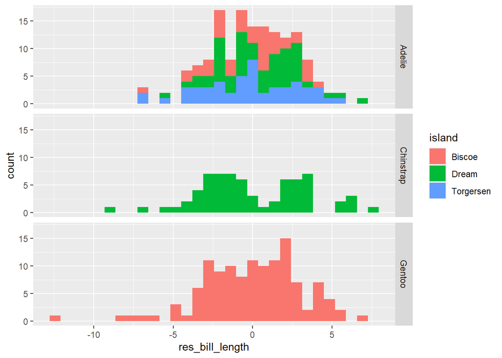

```r
pm %>%
  select(-starts_with("sd_")) %>%
  full_join(p1, by = join_by(species)) %>%
  mutate(res_bill_length = mean_bill_length - bill_length_mm,
         res_bill_depth = mean_bill_depth - bill_depth_mm
         ) %>%

  ggplot(aes(x = res_bill_length, fill = island)) +
  geom_histogram() +
  # costruisce frame come facet_wrap solo che posso indicare se separare i grafici per riga o per colonna
  facet_grid(rows = "species")
```

e se volesimo sapere la distribuzione in funzione sia della specie che dell’isola, ma ottenendo un grafico come il precedente? Unisco le colonne e creo una categoria “isola-specie” con la funzione `unite()` che unisce due colonne:

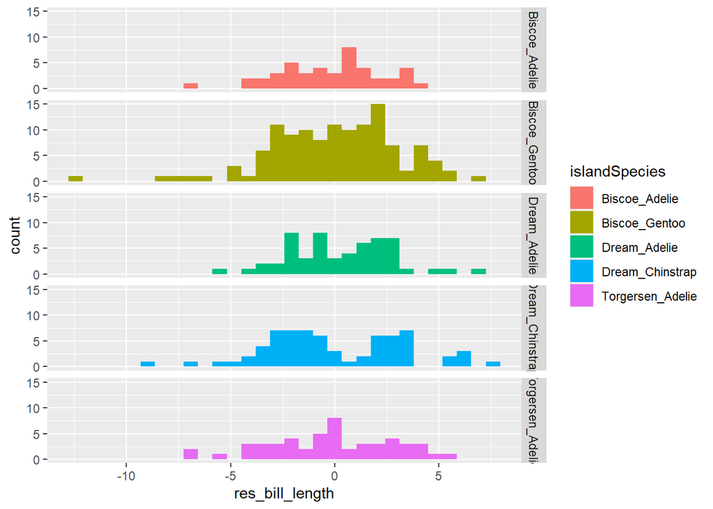

```r
# assegno alla variabile pl il grafico
pl <- pm %>%
  select(-starts_with("sd_")) %>%
  full_join(p1, by = join_by(species)) %>%
  mutate(res_bill_length = mean_bill_length - bill_length_mm,
         res_bill_depth = mean_bill_depth - bill_depth_mm
         ) %>%
  # unisci i valori nelle colonne island e species in un'unica colonna chiamata islandSpecies
  unite("islandSpecies", island, species) %>%

  ggplot(aes(res_bill_length, fill = islandSpecies)) + geom_histogram(position = position_dodge()) + facet_grid(rows = "islandSpecies")

pl # se richiamo la variabile ottengo il grafico
```

### ggsave()

Ora per salvare un grafico creato con ggplot possiamo usare la funzione ggsave insicando il nome del file con l’estensione, il grafico e l’estensione (device) dell’immagine salvata. Ad esempio per salvare il grafico precedente in png.

```
ggsave(filename = "plot1.png", plot = pl, device = "png")
```